# Capstone Project : Telco Customer Churn

Sona Nathani

15th April 2019

### Data Exploration/Preparation

#### Telco Customer Churn Data

Here are the sample records from the dataset.

|  | customerID | gender | SeniorCitizen | Partner | Dependents | tenure | PhoneService | MultipleLines | InternetService | OnlineSecurity | OnlineBackup | DeviceProtection | TechSupport | StreamingTV | StreamingMovies | Contract | PaperlessBilling | PaymentMethod | MonthlyCharges | TotalCharges | Churn |
| --- | --- | --- | --- | --- | --- | --- | --- | --- | --- | --- | --- | --- | --- | --- | --- | --- | --- | --- | --- | --- | --- |
| 1 | 7590-VHVEG | Female | 0 | Yes | No | 1 | No | No phone service | DSL | No | Yes | No | No | No | No | Month-to-month | Yes | Electronic check | 29.85 | 29.85 | No |
| 2 | 5575-GNVDE | Male | 0 | No | No | 34 | Yes | No | DSL | Yes | No | Yes | No | No | No | One year | No | Mailed check | 56.95 | 1889.50 | No |
| 3 | 3668-QPYBK | Male | 0 | No | No | 2 | Yes | No | DSL | Yes | Yes | No | No | No | No | Month-to-month | Yes | Mailed check | 53.85 | 108.15 | Yes |
| 4 | 7795-CFOCW | Male | 0 | No | No | 45 | No | No phone service | DSL | Yes | No | Yes | Yes | No | No | One year | No | Bank transfer (automatic) | 42.30 | 1840.75 | No |
| 5 | 9237-HQITU | Female | 0 | No | No | 2 | Yes | No | Fiber optic | No | No | No | No | No | No | Month-to-month | Yes | Electronic check | 70.70 | 151.65 | Yes |
| 6 | 9305-CDSKC | Female | 0 | No | No | 8 | Yes | Yes | Fiber optic | No | No | Yes | No | Yes | Yes | Month-to-month | Yes | Electronic check | 99.65 | 820.50 | Yes |
| 7 | 1452-KIOVK | Male | 0 | No | Yes | 22 | Yes | Yes | Fiber optic | No | Yes | No | No | Yes | No | Month-to-month | Yes | Credit card (automatic) | 89.10 | 1949.40 | No |
| 8 | 6713-OKOMC | Female | 0 | No | No | 10 | No | No phone service | DSL | Yes | No | No | No | No | No | Month-to-month | No | Mailed check | 29.75 | 301.90 | No |
| 9 | 7892-POOKP | Female | 0 | Yes | No | 28 | Yes | Yes | Fiber optic | No | No | Yes | Yes | Yes | Yes | Month-to-month | Yes | Electronic check | 104.80 | 3046.05 | Yes |
| 10 | 6388-TABGU | Male | 0 | No | Yes | 62 | Yes | No | DSL | Yes | Yes | No | No | No | No | One year | No | Bank transfer (automatic) | 56.15 | 3487.95 | No |

Structure of the dataset:

```
'data.frame':   7043 obs. of  21 variables:
 $ customerID      : Factor w/ 7043 levels "0002-ORFBO","0003-MKNFE",..: 5376 3963 2565 5536 6512 6552 1003 4771 5605 4535 ...
 $ gender          : Factor w/ 2 levels "Female","Male": 1 2 2 2 1 1 2 1 1 2 ...
 $ SeniorCitizen   : int  0 0 0 0 0 0 0 0 0 0 ...
 $ Partner         : Factor w/ 2 levels "No","Yes": 2 1 1 1 1 1 1 1 2 1 ...
 $ Dependents      : Factor w/ 2 levels "No","Yes": 1 1 1 1 1 1 2 1 1 2 ...
 $ tenure          : int  1 34 2 45 2 8 22 10 28 62 ...
 $ PhoneService    : Factor w/ 2 levels "No","Yes": 1 2 2 1 2 2 2 1 2 2 ...
 $ MultipleLines   : Factor w/ 3 levels "No","No phone service",..: 2 1 1 2 1 3 3 2 3 1 ...
 $ InternetService : Factor w/ 3 levels "DSL","Fiber optic",..: 1 1 1 1 2 2 2 1 2 1 ...
 $ OnlineSecurity  : Factor w/ 3 levels "No","No internet service",..: 1 3 3 3 1 1 1 3 1 3 ...
 $ OnlineBackup    : Factor w/ 3 levels "No","No internet service",..: 3 1 3 1 1 1 3 1 1 3 ...
 $ DeviceProtection: Factor w/ 3 levels "No","No internet service",..: 1 3 1 3 1 3 1 1 3 1 ...
 $ TechSupport     : Factor w/ 3 levels "No","No internet service",..: 1 1 1 3 1 1 1 1 3 1 ...
 $ StreamingTV     : Factor w/ 3 levels "No","No internet service",..: 1 1 1 1 1 3 3 1 3 1 ...
 $ StreamingMovies : Factor w/ 3 levels "No","No internet service",..: 1 1 1 1 1 3 1 1 3 1 ...
 $ Contract        : Factor w/ 3 levels "Month-to-month",..: 1 2 1 2 1 1 1 1 1 2 ...
 $ PaperlessBilling: Factor w/ 2 levels "No","Yes": 2 1 2 1 2 2 2 1 2 1 ...
 $ PaymentMethod   : Factor w/ 4 levels "Bank transfer (automatic)",..: 3 4 4 1 3 3 2 4 3 1 ...
 $ MonthlyCharges  : num  29.9 57 53.9 42.3 70.7 ...
 $ TotalCharges    : num  29.9 1889.5 108.2 1840.8 151.7 ...
 $ Churn           : Factor w/ 2 levels "No","Yes": 1 1 2 1 2 2 1 1 2 1 ...
```

```
      customerID           gender    SeniorCitizen          Partner       Dependents           tenure     PhoneService    MultipleLines  InternetService   OnlineSecurity     OnlineBackup DeviceProtection      TechSupport      StreamingTV  StreamingMovies         Contract PaperlessBilling    PaymentMethod   MonthlyCharges     TotalCharges            Churn
               0                0                0                0                0                0                0                0                0                0                0                0                0                0                0                0                0                0                0               11                0
```

### Data wrangling and missing value treatment

- Out of total records(7043), 11 records have missing values for “TotalCharges varibles”. Hence, we will remove those 11 records from the dataset.
- We will change “No internet service” to “No” for six columns, they are: “OnlineSecurity”, #“OnlineBackup”, “DeviceProtection”, “TechSupport”, “streamingTV”, “streamingMovies”.
- We will change “No phone service” to “No” for column “MultipleLines”.
- We will change the values in column “SeniorCitizen” from 0 or 1 to “No” or “Yes”.
- We do not need column “customerID” for the analysis, hence will remove this column.

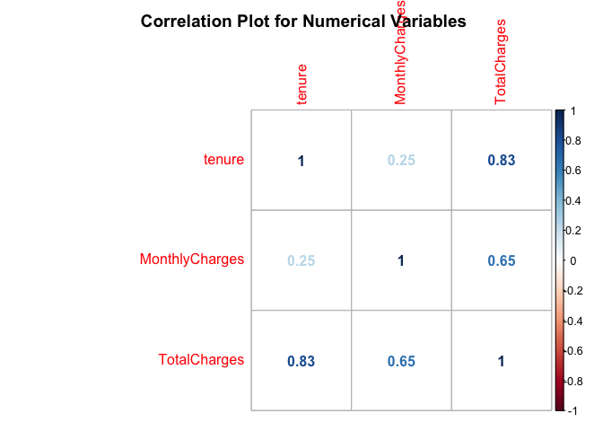

### Correlation between numeric variables

- Tenure and TotalCharges are highly correlated with a correlation value of more than 0.8. Hence, we will select Tenure as one of the model parameters and exclude TotalCharges.
- Tenure and MonthlyCharges are less correlated. Therefore, we will both these varibles as model parameters.

### Proportion comparision of categorical variables

[output not shown]

```
    Pearson's Chi-squared test with Yates' continuity correction

data:  Churn_Gender
X-squared = 0.47545, df = 1, p-value = 0.4905
```

```
    Pearson's Chi-squared test with Yates' continuity correction

data:  Churn_SeniorCitizen
X-squared = 158.44, df = 1, p-value < 2.2e-16
```

```
    Pearson's Chi-squared test with Yates' continuity correction

data:  Churn_Partner
X-squared = 157.5, df = 1, p-value < 2.2e-16
```

```
    Pearson's Chi-squared test with Yates' continuity correction

data:  Churn_Dependents
X-squared = 186.32, df = 1, p-value < 2.2e-16
```

```
    Pearson's Chi-squared test with Yates' continuity correction

data:  Churn_PhoneService
X-squared = 0.87373, df = 1, p-value = 0.3499
```

```
    Pearson's Chi-squared test with Yates' continuity correction

data:  Churn_MultipleLines
X-squared = 11.087, df = 1, p-value = 0.0008694
```

```
    Pearson's Chi-squared test

data:  Churn_InternetService
X-squared = 728.7, df = 2, p-value < 2.2e-16
```

```
    Pearson's Chi-squared test with Yates' continuity correction

data:  Churn_OnlineSecurity
X-squared = 205.42, df = 1, p-value < 2.2e-16
```

```
    Pearson's Chi-squared test with Yates' continuity correction

data:  Churn_OnlineBackup
X-squared = 47.247, df = 1, p-value = 6.259e-12
```

```
    Pearson's Chi-squared test with Yates' continuity correction

data:  Churn_DeviceProtection
X-squared = 30.496, df = 1, p-value = 3.346e-08
```

```
    Pearson's Chi-squared test with Yates' continuity correction

data:  Churn_TechSupport
X-squared = 189.97, df = 1, p-value < 2.2e-16
```

```
    Pearson's Chi-squared test with Yates' continuity correction

data:  Churn_StreamingTV
X-squared = 27.842, df = 1, p-value = 1.316e-07
```

```
    Pearson's Chi-squared test with Yates' continuity correction

data:  Churn_StreamingMovies
X-squared = 25.764, df = 1, p-value = 3.858e-07
```

```
    Pearson's Chi-squared test

data:  Churn_Contract
X-squared = 1179.5, df = 2, p-value < 2.2e-16
```

```
    Pearson's Chi-squared test with Yates' continuity correction

data:  Churn_PaperlessBilling
X-squared = 256.87, df = 1, p-value < 2.2e-16
```

```
    Pearson's Chi-squared test

data:  Churn_PaymentMethod
X-squared = 645.43, df = 3, p-value < 2.2e-16
```

Based on Pearson’s chi-squared test,Churn is strongly associated with most of the categorical variables expect Gender and PhoneService. Hence, we will not consider Gender and PhoneService as the model parameters.

#### Histogram of Tenure and Monthly Charges

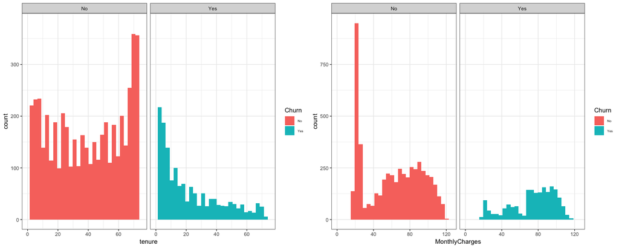

#### Density Plot of Tenure and Monthly Charges

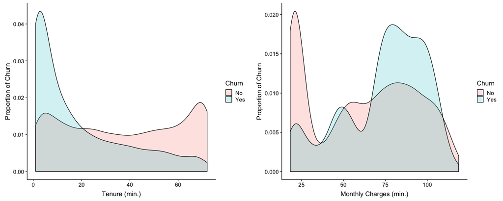

#### Based on the above Density Plots, Tenure and Monthly Charges is categorized into relevent groups.The comparision plots to show the proportion of Churn in each gropu is shown below:

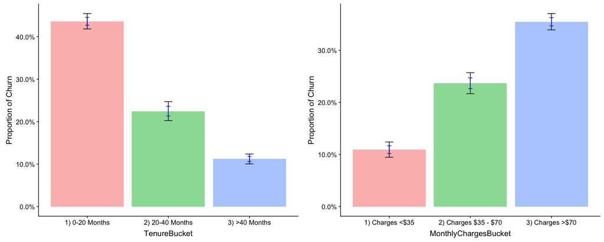

#### Logistic Regression Output

```
Logistic regression (GLM)
Data                 : dev
Response variable    : Churn
Level                : Yes in Churn
Explanatory variables: SeniorCitizen, Partner, Dependents, InternetService, OnlineSecurity, OnlineBackup, DeviceProtection, TechSupport, StreamingTV, StreamingMovies, Contract, PaperlessBilling, TenureBucket, MonthlyChargesBucket
Null hyp.: there is no effect of x on Churn
Alt. hyp.: there is an effect of x on Churn

                                              OR coefficient std.error z.value p.value
 (Intercept)                                          -0.192     0.193  -0.994   0.320
 SeniorCitizen|Yes                         1.218       0.197     0.099   1.993   0.046 *
 Partner|Yes                               0.948      -0.054     0.091  -0.595   0.552
 Dependents|Yes                            0.801      -0.222     0.105  -2.112   0.035 *
 InternetService|Fiber optic               2.984       1.093     0.180   6.071  < .001 ***
 InternetService|No                        0.238      -1.435     0.225  -6.381  < .001 ***
 OnlineSecurity|Yes                        0.653      -0.426     0.100  -4.252  < .001 ***
 OnlineBackup|Yes                          0.805      -0.216     0.090  -2.408   0.016 *
 DeviceProtection|Yes                      0.976      -0.024     0.093  -0.256   0.798
 TechSupport|Yes                           0.650      -0.431     0.104  -4.159  < .001 ***
 StreamingTV|Yes                           1.219       0.198     0.095   2.074   0.038 *
 StreamingMovies|Yes                       1.381       0.323     0.096   3.369  < .001 ***
 Contract|One year                         0.399      -0.920     0.127  -7.222  < .001 ***
 Contract|Two year                         0.164      -1.810     0.204  -8.876  < .001 ***
 PaperlessBilling|Yes                      1.508       0.411     0.088   4.658  < .001 ***
 TenureBucket|2) 20-40 Months              0.430      -0.845     0.108  -7.850  < .001 ***
 TenureBucket|3) >40 Months                0.336      -1.089     0.124  -8.811  < .001 ***
 MonthlyChargesBucket|2) Charges $35 - $70 0.637      -0.451     0.202  -2.235   0.025 *
 MonthlyChargesBucket|3) Charges >$70      0.530      -0.634     0.269  -2.352   0.019 *

Signif. codes:  0 '***' 0.001 '**' 0.01 '*' 0.05 '.' 0.1 ' ' 1

Pseudo R-squared: 0.27
Log-likelihood: -2083.111, AIC: 4204.222, BIC: 4327.75
Chi-squared: 1539.358 df(18), p.value < .001
Nr obs: 4,922

                                          coefficient   2.5%  97.5%   +/-
(Intercept)                                    -0.192 -0.576  0.184 0.376
SeniorCitizen|Yes                               0.197  0.003  0.391 0.194
Partner|Yes                                    -0.054 -0.231  0.124 0.178
Dependents|Yes                                 -0.222 -0.429 -0.017 0.206
InternetService|Fiber optic                     1.093  0.747  1.454 0.360
InternetService|No                             -1.435 -1.876 -0.993 0.442
OnlineSecurity|Yes                             -0.426 -0.624 -0.231 0.196
OnlineBackup|Yes                               -0.216 -0.393 -0.040 0.176
DeviceProtection|Yes                           -0.024 -0.206  0.159 0.182
TechSupport|Yes                                -0.431 -0.635 -0.229 0.202
StreamingTV|Yes                                 0.198  0.011  0.385 0.187
StreamingMovies|Yes                             0.323  0.135  0.511 0.188
Contract|One year                              -0.920 -1.173 -0.673 0.247
Contract|Two year                              -1.810 -2.225 -1.423 0.388
PaperlessBilling|Yes                            0.411  0.238  0.584 0.173
TenureBucket|2) 20-40 Months                   -0.845 -1.057 -0.635 0.210
TenureBucket|3) >40 Months                     -1.089 -1.333 -0.848 0.241
MonthlyChargesBucket|2) Charges $35 - $70      -0.451 -0.844 -0.052 0.399
MonthlyChargesBucket|3) Charges >$70           -0.634 -1.164 -0.107 0.527

                                          odds ratio  2.5% 97.5%
SeniorCitizen|Yes                              1.218 1.003 1.479
Partner|Yes                                    0.948 0.794 1.132
Dependents|Yes                                 0.801 0.651 0.983
InternetService|Fiber optic                    2.984 2.110 4.278
InternetService|No                             0.238 0.153 0.370
OnlineSecurity|Yes                             0.653 0.536 0.794
OnlineBackup|Yes                               0.805 0.675 0.961
DeviceProtection|Yes                           0.976 0.814 1.172
TechSupport|Yes                                0.650 0.530 0.796
StreamingTV|Yes                                1.219 1.011 1.469
StreamingMovies|Yes                            1.381 1.145 1.668
Contract|One year                              0.399 0.309 0.510
Contract|Two year                              0.164 0.108 0.241
PaperlessBilling|Yes                           1.508 1.269 1.794
TenureBucket|2) 20-40 Months                   0.430 0.347 0.530
TenureBucket|3) >40 Months                     0.336 0.264 0.428
MonthlyChargesBucket|2) Charges $35 - $70      0.637 0.430 0.950
MonthlyChargesBucket|3) Charges >$70           0.530 0.312 0.899
```

The odds ratio and the confidence intervals suggest that StreamingMovies|Yes, Contract of 1 &2 years,PaperlessBilling,TenureBucket 2&3 and TechSupport are significant predictors of customers who are likely to churn.

### AUC Curve

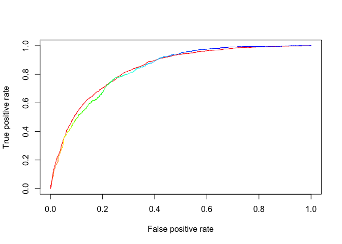

### Logistic Regression output

- **0.84** is the AUC for the development sample
- **0.84** is the AUC for the validation sample
- **0.75** is the accuracy of the development sample
- **0.75** is the accuracy of the validation sample